# Data Science Pipeline Presentation

Dominic Mancini

[output not shown]

## Problem

- Spam is a major issue in email communication, with 85% of emails classified as spam.
- Spam is not just a nuisance; it can lead to phishing, fraud, and information loss.
- A data breach that exposes 10 million records, costs $50 Million on average.<sup>1</sup>

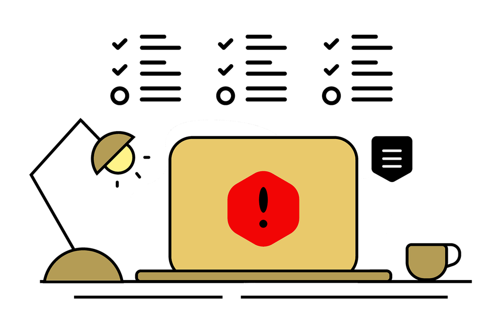

## Problem

Industries most affected by spam and phishing attacks include<sup>1</sup>:

- Finance
- Energy
- Retail
- Manufacturing

## Problem Context & Business Value

**Why it matters**:

- Spam detection prevents phishing, fraud, and information loss
- Phishing impacts businesses, employees, and their clients.
- Off-the-shelf solutions are often too rigid for small organizations.

## Project Overview

- **Goal**: Build a spam detection model using NLP and machine learning techniques.
- **Big Idea**: Modular, flexible spam detection pipelines to build bespoke email protection systems for organizations.

**Business Impact**:

- Custom models tailored to organisations’ needs
- Flexible solutions for small orgs with limited IT budgets
- Learn from real email flows

# Methodology

**Tools**:

- Python
- Scikit-learn
- Natural Language Toolkit (NLTK)
- Pandas
- Numpy
- Matplotlib, Seaborn

## Dataset

Nazario Email Dataset<sup>2</sup>

- Comprises over 5000 emails
- Emails from late 2000’s - 2020’s
- Compiled from various corpora
- Balanced dataset

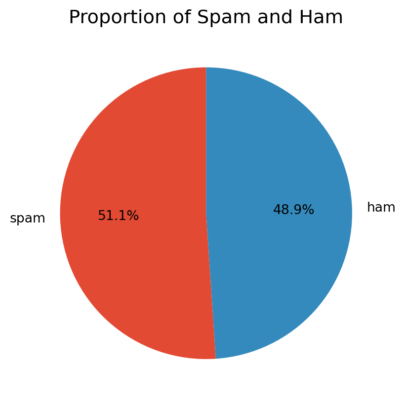

Email Class Makeup

## Pipeline

**Feature Engineering**

- Pre-Processing feature analysis:
  - Metadata analysis
- Text cleaning: lowercase, remove punctuation, stemming
- Feature Engineering:
  - TF-IDF of email body/subject
  - Structural features (URL count, subject reply, length)

**Models**

- Naive Bayes
- Logistic Regression
- Support Vector Machine (SVM)

## Design

`spam_detection` package:

- `data`: Data loading and processing
- `features`: Feature engineering and extraction
- `plots`: Visualization functions
- `textual_features`: A set of functions for text-based features
- `config`: Configuration settings and constants

## Design

`modeling` subpackage:

- `Modeler` class for model training and evaluation
  - Maintain state of trained models
  - Methods for training, predicting, evaluation
  - Saving and loading models
  - Hyperparameter tuning
  - Cross-validation
- OOP-based design for modularity and extensibility.
- Common interface for all models

```python
from spam_detection.modeling.model import Modeler
# Initialize with any model
my_modeler = Modeler(
    SVC(kernel='linear', random_state=42),
    random_state=42
)
my_modeler.train(X_train, y_train) # fit model on training set
my_modeler.evaluate(X_test, y_test) # predict and evaluate
my_modeler.confusion_matrix(y_test) # plot confusion matrix
my_modeler.roc_curve(y_test)
my_modeler.save_model("my_model.pkl") # save model to file
```

## Results

|  | Accuracy | Precision | Recall | F1-Score |
| --- | --- | --- | --- | --- |
| Naive Bayes | 0.966 | 0.957 | 0.973 | 0.965 |
| Logistic Reg. | 0.989 | 0.983 | 0.993 | 0.988 |
| SVM | 0.987 | 0.983 | 0.990 | 0.987 |

## Demo

To see the model in action, here are two fake emails:

```
Dear User,

We detected unusual activity in your email account. Immediate verification is required to avoid suspension.

Please confirm your credentials at:
http://securelogin-alert.com/verify

Failure to comply will result in permanent deactivation.

Thank you,
Email Security Team
```

```
Hi,

Thanks for sending over the draft. I've reviewed the project timeline and added
a few comments in the doc. Let me k now if you'd prefer to walk through them
together tomorrow or async.

Best,
Alex
```

## Demo

Let’s see how the model performs on these emails:

```
Predictions:  [1 0]
Prediction Probabilities:  ['96.63' '4.25']
```

```
Actual Labels:  ['spam' 'ham']
Predicted Labels:  ['spam' 'ham']
```

**Findings**

- Two realistic emails were evaluated.
- Successfully classified labels as as spam and ham.

The model is;

- 96.63% sure that the first email is spam.
- 4.25% sure that the second email is spam.

## Reflections

- Built a modular spam detection pipeline using NLP & ML
- Achieved high performance across multiple models
- Logistic Regression performed best overall
- Word-based and structural features both contributed
- `Modeler` class provides a common interface for all models

## Real-World Value

- Custom filters tailored to organizational patterns
- Adaptable for SMEs, NGOs, or security-conscious teams
- Easy to integrate into existing systems and workflows
- Learn directly from organization’s internal flow

## Future Work

- Explore deep learning approaches
- Build a more robust pipeline
- Integrate with existing email systems (e.g., Outlook, Gmail)
- User feedback loop for continuous improvement

## References

1. Griffiths, C. (2025). The Latest Phishing Statistics (updated January 2025). In *AAG-IT*. https://aag-it.com/the-latest-phishing-statistics/

2. Arifa Islam, C. (2023). *Phishing email curated datasets*. Zenodo. https://doi.org/10.5281/zenodo.8339691